# Arica y Parinacota

De acuerdo a la Figura 4, La mayor parte de la inversión se destina a la Dirección de Vialidad, lo que refleja la importancia de mejorar las vías de transporte para el desarrollo regional. La menor inversión en las Direcciones General de Concesiones, de Aguas y de Aeropuertos sugiere que estos proyectos tienen una prioridad más baja.

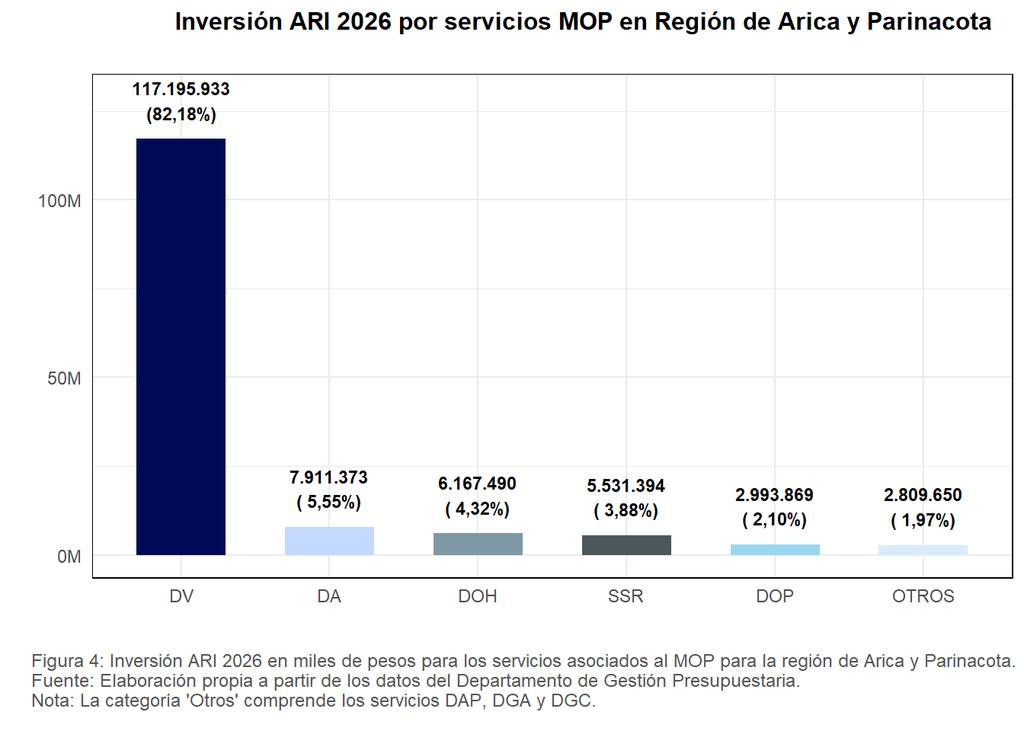

| Servicio | Inversión | Porcentaje (%) |
| --- | --- | --- |
| DAP | 1.388.690 | 0,97 |
| DGA | 927.564 | 0,65 |
| DGC | 493.396 | 0,35 |

Tabla 3: Inversión ARI 2026 en miles de pesos por Servicios MOP. Nota 1: Servicios MOP agrupados en ‘Otros’, los cuales incluyen DAP, DGA y DGC para la región de Arica y Parinacota. Nota 2: Montos en miles de pesos. Fuente: Tabla construida a partir de los datos del Departamento de Gestión Presupuestaria.

| Comuna | Población 2024 | Población 2025 | Crec/Decrec relativo (%) de Población 2024 al 2025 | Pobreza Multidimensional | Inversión |
| --- | --- | --- | --- | --- | --- |
| ARICA | 241.653 | 259.064 | 7,20 | 46.570 | 78.735.417 |
| CAMARONES | 861 | 1.248 | 44,95 | 460 | 5.864.697 |
| GENERAL LAGOS | 508 | 797 | 56,89 | 392 | S/I |
| PUTRE | 1.547 | 2.578 | 66,65 | 664 | 5.742.535 |

Tabla 4: Poblaciones, pobreza e inversión ARI 2026 (en miles de pesos) en la región de Arica y Parinacota. Fuente: Elaboración propia basada en datos del INE, del Departamento de Gestión Presupuestaria y CASEN 2022. (*) Población proyectada al 2025 según el INE. (**) Indica la cantidad estimada de personas en situación de pobreza multidimensional para el año 2022. Nota: Los valores ‘S/I’ en la columna Inversión corresponden a comunas que forman parte de proyectos intercomunales pero que no tienen un monto asociado.

# Tarapacá

La mayor parte de la inversión se destina a la Dirección de Vialidad, lo que refleja la importancia de mejorar las vías de transporte para el desarrollo regional. La menor inversión en las Direcciones General de Aguas, de Arquitectura y General de Concesiones sugiere que estos proyectos tienen una prioridad más baja.

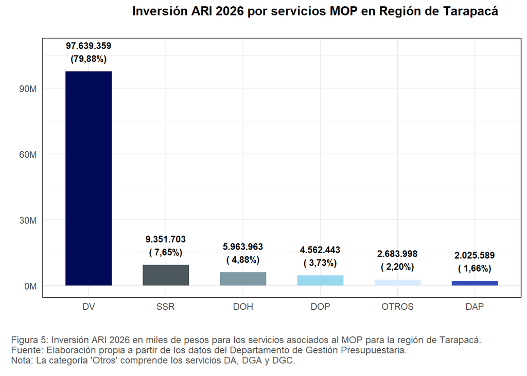

| Servicio | Inversión | Porcentaje (%) |
| --- | --- | --- |
| DA | 1.101.250 | 0,90 |
| DGA | 371.870 | 0,30 |
| DGC | 1.210.878 | 0,99 |

Tabla 5: Inversión ARI 2026 en miles de pesos por Servicios MOP. Nota 1: Servicios MOP agrupados en ‘Otros’, los cuales incluyen DA, DGA y DGC para la región de Tarapacá. Nota 2: Montos en miles de pesos. Fuente: Tabla construida a partir de los datos del Departamento de Gestión Presupuestaria.

| Comuna | Población 2024 | Población 2025 | Crec/Decrec relativo (%) de Población 2024 al 2025 | Pobreza Multidimensional | Inversión |
| --- | --- | --- | --- | --- | --- |
| ALTO HOSPICIO | 142.086 | 146.337 | 2,99 | 45.162 | 10.000 |
| CAMIÑA | 1.335 | 1.371 | 2,70 | 308 | 1.066.463 |
| COLCHANE | 790 | 1.546 | 95,70 | 473 | 3.298.658 |
| HUARA | 2.858 | 3.111 | 8,85 | 1.185 | 43.741.671 |
| IQUIQUE | 199.587 | 233.228 | 16,86 | 41.967 | 36.557.203 |
| PICA | 6.272 | 6.348 | 1,21 | 1.040 | 544.732 |
| POZO ALMONTE | 16.878 | 18.962 | 12,35 | 4.563 | 1.789.692 |

Tabla 6: Poblaciones, pobreza e inversión ARI 2026 (en miles de pesos) en la región de Tarapacá. Fuente: Elaboración propia basada en datos del INE, del Departamento de Gestión Presupuestaria y CASEN 2022. (*) Población proyectada al 2025 según el INE. (**) Indica la cantidad estimada de personas en situación de pobreza multidimensional para el año 2022.

# Antofagasta

En esta región, de acuerdo a la Figura 6, La mayor parte de la inversión se destina a la Dirección de Vialidad, lo que refleja la importancia de mejorar las vías de transporte para el desarrollo regional. La menor inversión en las Direcciones General de Aguas de Arquitectura y de Obras Portuarias sugiere que estos proyectos tienen una prioridad más baja.

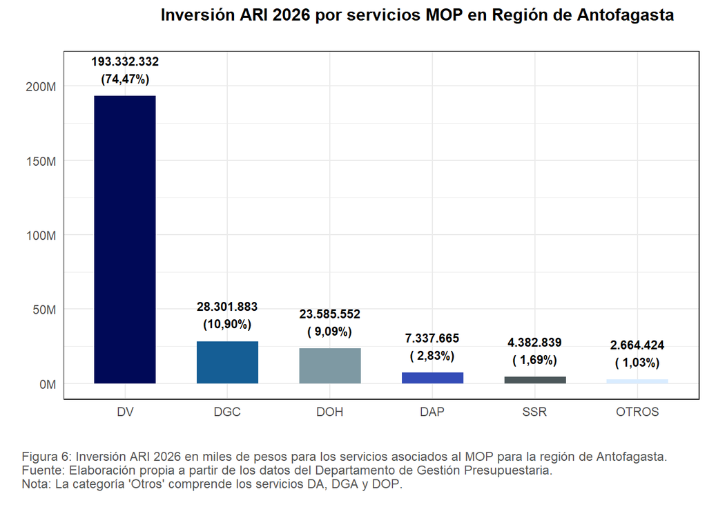

| Servicio | Inversión | Porcentaje (%) |
| --- | --- | --- |
| DA | 386.724 | 0,15 |
| DGA | 130.000 | 0,05 |
| DOP | 2.147.700 | 0,83 |

Tabla 7: Inversión ARI 2026 en miles de pesos por Servicios MOP. Nota 1: Servicios MOP agrupados en ‘Otros’, los cuales incluyen DA, DGA y DOP para la región de Antofagasta. Nota 2: Montos en miles de pesos. Fuente: Tabla construida a partir de los datos del Departamento de Gestión Presupuestaria.

| Comuna | Población 2024 | Población 2025 | Crec/Decrec relativo (%) de Población 2024 al 2025 | Pobreza Multidimensional | Inversión |
| --- | --- | --- | --- | --- | --- |
| ANTOFAGASTA | 401.096 | 447.224 | 11,50 | 73.103 | 15.041.175 |
| CALAMA | 166.334 | 196.820 | 18,33 | 32.668 | 21.810.262 |
| MARIA ELENA | 4.834 | 6.429 | 33,00 | 1.009 | 16.316.418 |
| MEJILLONES | 14.084 | 16.087 | 14,22 | 3.078 | 5.455.726 |
| OLLAGUE | 256 | 265 | 3,52 | 45 | 25.200 |
| SAN PEDRO DE ATACAMA | 9.843 | 11.121 | 12,98 | 2.440 | 8.716.613 |
| SIERRA GORDA | 1.472 | 1.806 | 22,69 | 295 | 20.586.408 |
| TALTAL | 12.097 | 13.999 | 15,72 | 2.938 | 1.725.935 |
| TOCOPILLA | 25.400 | 28.369 | 11,69 | 5.805 | 10.908.000 |

Tabla 8: Poblaciones, pobreza e inversión ARI 2026 (en miles de pesos) en la región de Antofagasta. Fuente: Elaboración propia basada en datos del INE, del Departamento de Gestión Presupuestaria y CASEN 2022. (*) Población proyectada al 2025 según el INE. (**) Indica la cantidad estimada de personas en situación de pobreza multidimensional para el año 2022.

# Atacama

Se aprecia en la Figura 7que La mayor parte de la inversión se destina a la Dirección de Vialidad, lo que refleja la importancia de mejorar las vías de transporte para el desarrollo regional. La menor inversión en las Direcciones de Obras Portuarias y en la Dirección de Arquitectura sugiere que estos proyectos tienen una prioridad más baja.

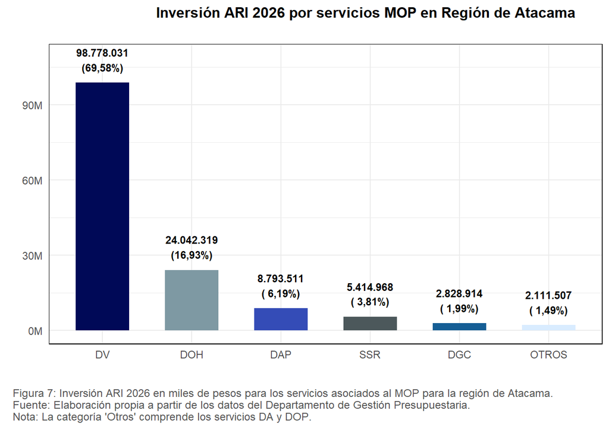

| Servicio | Inversión | Porcentaje (%) |
| --- | --- | --- |
| DA | 1.773.689 | 1,2 |
| DOP | 337.818 | 0,2 |

Tabla 9: Inversión ARI 2026 en miles de pesos por Servicios MOP. Nota 1: Servicios MOP agrupados en ‘Otros’, los cuales incluyen DA y DOP para la región de Atacama. Nota 2: Montos en miles de pesos. Fuente: Tabla construida a partir de los datos del Departamento de Gestión Presupuestaria.

| Comuna | Población 2024 | Población 2025 | Crec/Decrec relativo (%) de Población 2024 al 2025 | Pobreza Multidimensional | Inversión |
| --- | --- | --- | --- | --- | --- |
| ALTO DEL CARMEN | 4.788 | 5.785 | 20,82 | 1.607 | 4.808.748 |
| CALDERA | 18.805 | 20.057 | 6,66 | 3.890 | 5.422.282 |
| CHAÑARAL | 12.345 | 12.971 | 5,07 | 2.985 | 2.334.099 |
| COPIAPO | 168.831 | 176.921 | 4,79 | 34.634 | 45.222.353 |
| DIEGO DE ALMAGRO | 11.397 | 13.806 | 21,14 | 2.667 | 78.169 |
| FREIRINA | 7.577 | 7.865 | 3,80 | 2.225 | 241.667 |
| HUASCO | 9.369 | 11.650 | 24,35 | 2.045 | 927.948 |
| TIERRA AMARILLA | 11.846 | 14.441 | 21,91 | 4.972 | 2.519.638 |
| VALLENAR | 54.222 | 57.368 | 5,80 | 9.457 | 4.949.926 |

Tabla 10: Poblaciones, pobreza e inversión ARI 2026 (en miles de pesos) en la región de Atacama. Fuente: Elaboración propia basada en datos del INE, del Departamento de Gestión Presupuestaria y CASEN 2022. (*) Población proyectada al 2025 según el INE. (**) Indica la cantidad estimada de personas en situación de pobreza multidimensional para el año 2022.

# Coquimbo

De acuerdo a la Figura 8, La mayor parte de la inversión se destina a la Dirección de Vialidad, lo que refleja la importancia de mejorar las vías de transporte para el desarrollo regional. La menor inversión en las Direcciones de Planeamiento, General de Aguas y de Arquitectura sugiere que estos proyectos tienen una prioridad más baja.

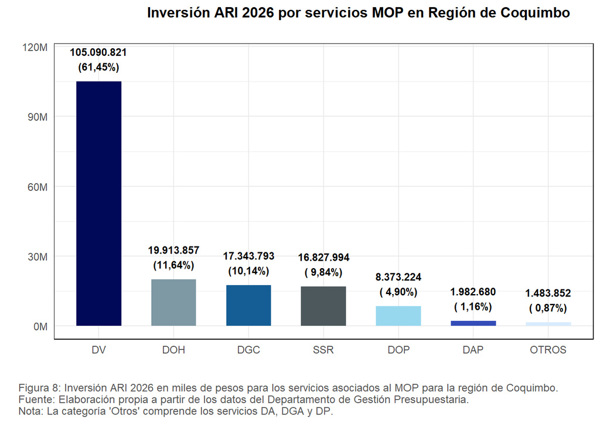

| Servicio | Inversión | Porcentaje (%) |
| --- | --- | --- |
| DA | 1.032.904 | 0,60 |
| DGA | 265.748 | 0,16 |
| DP | 185.200 | 0,11 |

Tabla 11: Inversión ARI 2026 en miles de pesos por Servicios MOP. Nota 1: Servicios MOP agrupados en ‘Otros’, los cuales incluyen DA, DGA y DP para la región de Coquimbo. Nota 2: Montos en miles de pesos. Fuente: Tabla construida a partir de los datos del Departamento de Gestión Presupuestaria.

| Comuna | Población 2024 | Población 2025 | Crec/Decrec relativo (%) de Población 2024 al 2025 | Pobreza Multidimensional | Inversión |
| --- | --- | --- | --- | --- | --- |
| ANDACOLLO | 11.566 | 11.838 | 2,35 | 2.287 | 511.006 |
| CANELA | 9.639 | 9.494 | -1,50 | 2.277 | 299.990 |
| COMBARBALA | 12.954 | 13.839 | 6,83 | 3.110 | 8.753.797 |
| COQUIMBO | 263.719 | 280.153 | 6,23 | 44.874 | 4.735.852 |
| ILLAPEL | 32.009 | 33.051 | 3,26 | 5.591 | 2.294.852 |
| LA HIGUERA | 4.335 | 4.548 | 4,91 | 1.331 | 4.834.116 |
| LA SERENA | 250.141 | 271.608 | 8,58 | 34.151 | 18.393.037 |
| LOS VILOS | 22.879 | 24.641 | 7,70 | 5.026 | 2.860.837 |
| MONTE PATRIA | 29.997 | 32.682 | 8,95 | 7.570 | 541.767 |
| OVALLE | 118.696 | 125.046 | 5,35 | 22.146 | 3.432.265 |
| PAIGUANO | 4.649 | 4.713 | 1,38 | 711 | 929.270 |
| PUNITAQUI | 12.076 | 12.585 | 4,21 | 3.319 | 2.213.414 |
| RIO HURTADO | 4.334 | 4.291 | -0,99 | 988 | 100.463 |
| SALAMANCA | 27.823 | 30.081 | 8,12 | 4.145 | S/I |
| VICUÑA | 28.047 | 30.703 | 9,47 | 5.888 | 8.928.638 |

Tabla 12: Poblaciones, pobreza e inversión ARI 2026 (en miles de pesos) en la región de Coquimbo. Fuente: Elaboración propia basada en datos del INE, del Departamento de Gestión Presupuestaria y CASEN 2022. (*) Población proyectada al 2025 según el INE. (**) Indica la cantidad estimada de personas en situación de pobreza multidimensional para el año 2022. Nota: Los valores ‘S/I’ en la columna Inversión corresponden a comunas que forman parte de proyectos intercomunales pero que no tienen un monto asociado.

# Valparaíso

Según la Figura 9, La mayor parte de la inversión se destina a la Dirección de Vialidad, lo que refleja la importancia de mejorar las vías de transporte para el desarrollo regional. La menor inversión en las Direcciones General de Aguas y de Aeropuertos sugiere que estos proyectos tienen una prioridad más baja.

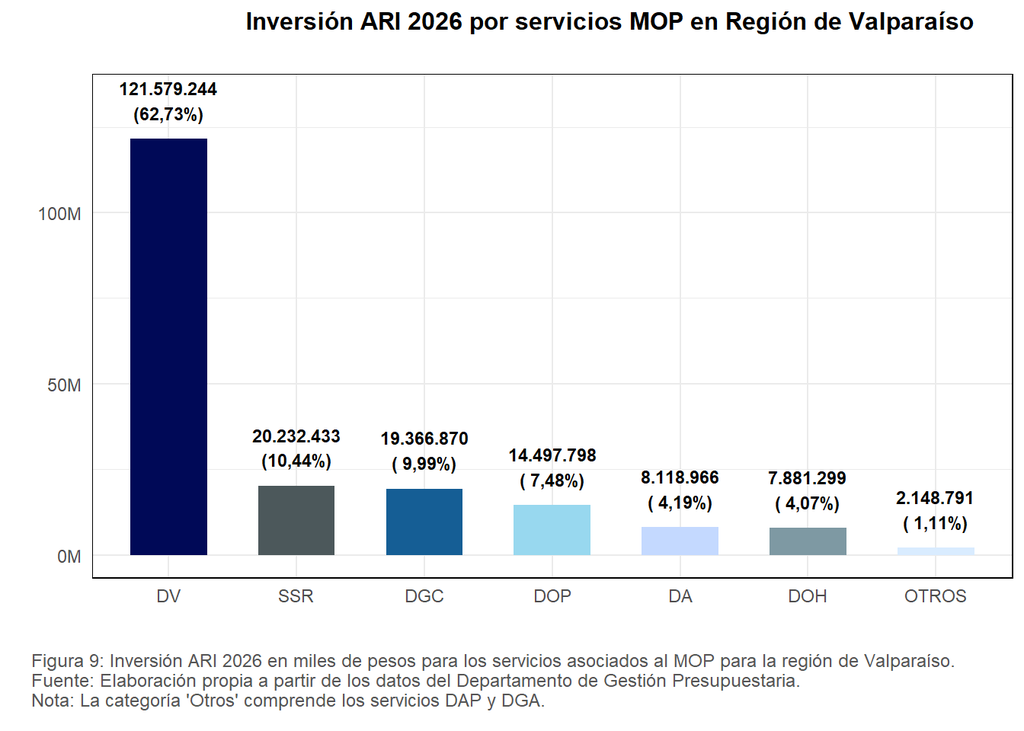

| Servicio | Inversión | Porcentaje (%) |
| --- | --- | --- |
| DAP | 1.944.685 | 1,00 |
| DGA | 204.106 | 0,11 |

Tabla 13: Inversión ARI 2026 en miles de pesos por Servicios MOP. Nota 1: Servicios MOP agrupados en ‘Otros’, los cuales incluyen DAP, DGA para la región de Valparaíso. Nota 2: Montos en miles de pesos. Fuente: Tabla construida a partir de los datos del Departamento de Gestión Presupuestaria.

| Comuna | Población 2024 | Población 2025 | Crec/Decrec relativo (%) de Población 2024 al 2025 | Pobreza Multidimensional | Inversión |
| --- | --- | --- | --- | --- | --- |
| ALGARROBO | 16.076 | 16.296 | 1,37 | 3.079 | S/I |
| CABILDO | 20.015 | 20.764 | 3,74 | 4.262 | 2.421.321 |
| CALERA | 50.631 | 53.945 | 6,55 | 9.000 | S/I |
| CALLE LARGA | 16.597 | 17.946 | 8,13 | 2.492 | S/I |
| CARTAGENA | 24.599 | 27.476 | 11,70 | 7.492 | S/I |
| CASABLANCA | 29.876 | 30.861 | 3,30 | 5.891 | 246.358 |
| CATEMU | 13.760 | 15.824 | 15,00 | 2.866 | 1.893.152 |
| CONCON | 48.294 | 48.704 | 0,85 | 6.341 | 153.250 |
| EL QUISCO | 18.971 | 19.073 | 0,54 | 2.161 | 836.488 |
| EL TABO | 16.260 | 15.375 | -5,44 | 3.082 | S/I |
| HIJUELAS | 19.286 | 19.537 | 1,30 | 4.321 | 3.044.844 |
| ISLA DE PASCUA | 4.800 | 8.997 | 87,44 | 1.080 | 18.670.012 |
| JUAN FERNANDEZ | 904 | 1.121 | 24,00 | 61 | 2.442.652 |
| LA CRUZ | 24.939 | 28.505 | 14,30 | 3.758 | 299.708 |
| LA LIGUA | 39.270 | 38.511 | -1,93 | 9.013 | 2.429.606 |
| LIMACHE | 56.145 | 52.099 | -7,21 | 8.985 | 2.850.444 |
| LLAILLAY | 25.484 | 27.449 | 7,71 | 4.199 | S/I |
| LOS ANDES | 63.440 | 69.094 | 8,91 | 10.429 | 3.778.638 |
| NOGALES | 22.136 | 23.665 | 6,91 | 3.559 | 1.654.851 |
| OLMUE | 19.778 | 20.480 | 3,55 | 5.191 | 1.989.641 |
| PANQUEHUE | 7.269 | 7.889 | 8,53 | 1.417 | 70.000 |
| PAPUDO | 7.561 | 6.492 | -14,14 | 1.198 | 1.196.241 |
| PETORCA | 10.206 | 10.636 | 4,21 | 1.745 | S/I |
| PUCHUNCAVI | 22.539 | 21.490 | -4,65 | 6.568 | S/I |
| PUTAENDO | 17.336 | 18.097 | 4,39 | 4.146 | 1.116.358 |
| QUILLOTA | 96.753 | 101.729 | 5,14 | 15.434 | S/I |
| QUILPUE | 162.559 | 175.095 | 7,71 | 27.434 | 4.487.036 |
| QUINTERO | 35.754 | 39.170 | 9,55 | 8.825 | 100 |
| RINCONADA | 11.855 | 12.204 | 2,94 | 2.946 | S/I |
| SAN ANTONIO | 96.770 | 98.992 | 2,30 | 13.922 | 9.740.524 |
| SAN ESTEBAN | 20.112 | 22.010 | 9,44 | 4.473 | 1.118.153 |
| SAN FELIPE | 80.413 | 87.601 | 8,94 | 14.722 | 318.000 |
| SANTA MARIA | 15.134 | 17.097 | 12,97 | 3.312 | S/I |
| SANTO DOMINGO | 13.171 | 12.758 | -3,14 | 1.994 | 5.228.716 |
| VALPARAISO | 284.938 | 321.852 | 12,96 | 60.901 | 15.633.150 |
| VILLA ALEMANA | 139.571 | 149.327 | 6,99 | 21.593 | S/I |
| VIÑA DEL MAR | 334.871 | 373.551 | 11,55 | 54.771 | 1.200.000 |
| ZAPALLAR | 7.980 | 8.454 | 5,94 | 2.194 | 410.534 |

Tabla 14: Poblaciones, pobreza e inversión ARI 2026 (en miles de pesos) en la región de Valparaíso. Fuente: Elaboración propia basada en datos del INE, del Departamento de Gestión Presupuestaria y CASEN 2022. (*) Población proyectada al 2025 según el INE. (**) Indica la cantidad estimada de personas en situación de pobreza multidimensional para el año 2022. Nota: Los valores ‘S/I’ en la columna Inversión corresponden a comunas que forman parte de proyectos intercomunales pero que no tienen un monto asociado.

# Metropolitana de Santiago

La mayor parte de la inversión se destina a la Dirección General de Concesiones y a la Dirección de Vialidad, lo que refleja la importancia de mejorar las vías de transporte y de tener infraestructuras para el desarrollo regional. La menor inversión en las Direcciones de Planeamiento y General de Aguas sugiere que estos proyectos tienen una prioridad más baja.

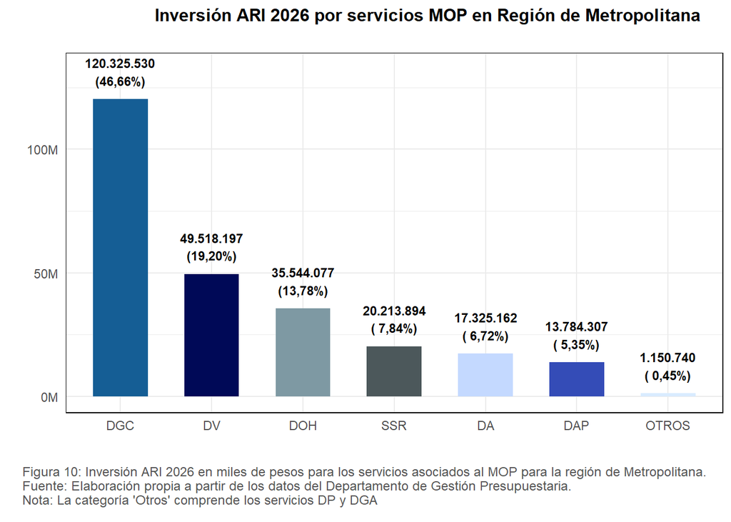

| Servicio | Inversión | Porcentaje (%) |
| --- | --- | --- |
| DGA | 940.740 | 0,36 |
| DP | 210.000 | 0,08 |

Tabla 15: Inversión ARI 2026 en miles de pesos por Servicios MOP. Nota: Servicios MOP agrupados en ‘Otros’, los cuales incluyen DP y DGA para la región Metropolitana. Nota 2: Montos en miles de pesos Fuente: Tabla construida a partir de los datos del Departamento de Gestión Presupuestaria.

| Comuna | Población 2024 | Población 2025 | Crec/Decrec relativo (%) de Población 2024 al 2025 | Pobreza Multidimensional | Inversión |
| --- | --- | --- | --- | --- | --- |
| ALHUE | 7.768 | 7.954 | 2,39 | 2.239 | S/I |
| BUIN | 116.969 | 119.885 | 2,49 | 21.956 | S/I |
| CALERA DE TANGO | 25.491 | 30.678 | 20,35 | 5.508 | S/I |
| CERRILLOS | 85.041 | 90.268 | 6,15 | 20.277 | S/I |
| CERRO NAVIA | 127.250 | 138.677 | 8,98 | 32.490 | 821.098 |
| COLINA | 173.293 | 201.012 | 16,00 | 47.025 | 84.207 |
| CONCHALI | 121.587 | 135.654 | 11,57 | 25.877 | S/I |
| CURACAVI | 35.165 | 38.803 | 10,35 | 9.730 | 800.000 |
| EL BOSQUE | 155.257 | 169.168 | 8,96 | 29.869 | 300.000 |
| EL MONTE | 37.497 | 42.723 | 13,94 | 9.505 | 1.894.550 |
| ESTACION CENTRAL | 181.049 | 223.849 | 23,64 | 49.849 | 1.849.371 |
| HUECHURABA | 101.808 | 119.487 | 17,37 | 21.698 | 279.613 |
| INDEPENDENCIA | 116.943 | 155.387 | 32,87 | 33.806 | S/I |
| ISLA DE MAIPO | 39.274 | 42.887 | 9,20 | 9.505 | S/I |
| LA CISTERNA | 103.157 | 101.398 | -1,71 | 13.650 | 3.349.171 |
| LA FLORIDA | 374.836 | 407.764 | 8,78 | 53.467 | 188.218 |
| LA GRANJA | 112.022 | 118.394 | 5,69 | 26.942 | S/I |
| LA PINTANA | 175.421 | 188.806 | 7,63 | 51.087 | S/I |
| LA REINA | 89.870 | 98.722 | 9,85 | 4.895 | S/I |
| LAMPA | 145.160 | 146.646 | 1,02 | 35.084 | 1.924.920 |
| LAS CONDES | 296.134 | 345.985 | 16,83 | 15.049 | S/I |
| LO BARNECHEA | 112.620 | 132.248 | 17,43 | 14.045 | S/I |
| LO ESPEJO | 87.295 | 99.774 | 14,30 | 29.398 | 339.223 |
| LO PRADO | 91.290 | 101.223 | 10,88 | 19.978 | 2.800.000 |
| MACUL | 123.800 | 138.951 | 12,24 | 18.467 | S/I |
| MAIPU | 503.635 | 587.189 | 16,59 | 86.976 | 7.830.202 |
| MARIA PINTO | 15.352 | 15.838 | 3,17 | 4.178 | 6.347 |
| MELIPILLA | 136.325 | 150.466 | 10,37 | 33.360 | 5.590.244 |
| PADRE HURTADO | 81.243 | 83.549 | 2,84 | 15.418 | S/I |
| PAINE | 78.828 | 89.543 | 13,59 | 18.070 | 2.510.000 |
| PEDRO AGUIRRE CERDA | 96.062 | 103.434 | 7,67 | 21.398 | S/I |
| PEÑAFLOR | 94.402 | 108.142 | 14,55 | 15.840 | S/I |
| PEÑALOLEN | 236.478 | 273.909 | 15,83 | 45.120 | S/I |
| PIRQUE | 29.060 | 33.617 | 15,68 | 6.222 | 10.250.000 |
| PROVIDENCIA | 143.974 | 165.134 | 14,70 | 7.004 | 3.407.298 |
| PUDAHUEL | 227.820 | 262.943 | 15,42 | 43.744 | 17.612.839 |
| PUENTE ALTO | 568.086 | 671.142 | 18,14 | 125.235 | S/I |
| QUILICURA | 205.624 | 279.737 | 36,04 | 45.807 | S/I |
| QUINTA NORMAL | 129.351 | 142.670 | 10,30 | 27.628 | S/I |
| RECOLETA | 154.615 | 197.824 | 27,95 | 41.371 | 171.866 |
| RENCA | 143.622 | 163.267 | 13,68 | 31.710 | S/I |
| SAN BERNARDO | 306.371 | 351.625 | 14,77 | 64.276 | 60.000 |
| SAN JOAQUIN | 95.602 | 102.811 | 7,54 | 20.317 | S/I |
| SAN JOSE DE MAIPO | 17.441 | 19.700 | 12,95 | 4.688 | 2.345.699 |
| SAN MIGUEL | 150.829 | 148.387 | -1,62 | 18.200 | S/I |
| SAN PEDRO | 11.108 | 12.669 | 14,05 | 3.939 | 3.442.928 |
| SAN RAMON | 76.002 | 82.919 | 9,10 | 16.283 | S/I |
| SANTIAGO | 438.856 | 552.151 | 25,82 | 87.355 | 16.451.510 |
| TALAGANTE | 76.429 | 86.348 | 12,98 | 14.297 | 2.863.965 |
| TILTIL | 19.742 | 22.695 | 14,96 | 6.393 | S/I |
| VITACURA | 86.420 | 96.671 | 11,86 | 2.382 | 400.000 |
| ÑUÑOA | 241.467 | 270.521 | 12,03 | 13.496 | S/I |

Tabla 16: Poblaciones, pobreza e inversión ARI 2026 (en miles de pesos) en la región Metropolitana. Fuente: Elaboración propia basada en datos del INE, del Departamento de Gestión Presupuestaria y CASEN 2022. (*) Población proyectada al 2025 según el INE. (**) Indica la cantidad estimada de personas en situación de pobreza multidimensional para el año 2022. Nota: Los valores ‘S/I’ en la columna Inversión corresponden a comunas que forman parte de proyectos intercomunales pero que no tienen un monto asociado.

# Libertador General Bernardo O’Higgins

La mayor parte de la inversión se destina a la Dirección de Vialidad, lo que refleja la importancia de mejorar las vías de transporte para el desarrollo regional. La menor inversión en las Direcciones de Aeropuertos de Arquitectura, General de Aguas y de Obras portuarias sugiere que estos proyectos tienen una prioridad más baja.

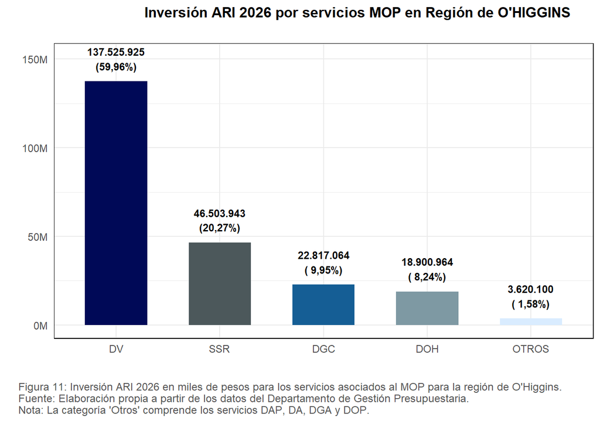

| Servicio | Inversión | Porcentaje (%) |
| --- | --- | --- |
| DA | 620.034 | 0,27 |
| DAP | 559.887 | 0,24 |
| DGA | 1.140.107 | 0,50 |
| DOP | 1.300.072 | 0,57 |

Tabla 17: Inversión ARI 2026 en miles de pesos por Servicios MOP. Nota 1: Servicios MOP agrupados en ‘Otros’, los cuales incluyen DAP, DA, DGA y DOP para la región de O’Higgins. Nota 2: Montos en miles de pesos Fuente: Tabla construida a partir de los datos del Departamento de Gestión Presupuestaria.

| Comuna | Población 2024 | Población 2025 | Crec/Decrec relativo (%) de Población 2024 al 2025 | Pobreza Multidimensional | Inversión |
| --- | --- | --- | --- | --- | --- |
| CHEPICA | 15.668 | 16.189 | 3,33 | 2.630 | 1.620.818 |
| CHIMBARONGO | 37.258 | 38.602 | 3,61 | 6.662 | 1.491.234 |
| CODEGUA | 13.955 | 14.745 | 5,66 | 2.618 | 308.000 |
| COINCO | 7.916 | 8.062 | 1,84 | 1.740 | S/I |
| COLTAUCO | 21.373 | 22.347 | 4,56 | 3.579 | 2.312.397 |
| DOÑIHUE | 21.925 | 23.866 | 8,85 | 3.505 | S/I |
| GRANEROS | 35.938 | 38.569 | 7,32 | 4.981 | 45.000 |
| LA ESTRELLA | 4.609 | 3.092 | -32,91 | 494 | 78.113 |
| LAS CABRAS | 27.554 | 27.972 | 1,52 | 4.505 | 1.002.199 |
| LITUECHE | 8.852 | 6.989 | -21,05 | 1.918 | 2.400.000 |
| LOLOL | 7.791 | 7.489 | -3,88 | 1.629 | 5.469.575 |
| MACHALI | 60.875 | 65.812 | 8,11 | 8.109 | 3.261.332 |
| MALLOA | 13.882 | 14.325 | 3,19 | 1.910 | 400.808 |
| MARCHIHUE | 8.715 | 7.730 | -11,30 | 1.285 | 15.012.649 |
| MOSTAZAL | 27.394 | 28.806 | 5,15 | 5.920 | 5.858.732 |
| NANCAGUA | 18.723 | 19.855 | 6,05 | 3.026 | S/I |
| NAVIDAD | 8.885 | 7.188 | -19,10 | 1.456 | 5.578.562 |
| OLIVAR | 13.901 | 15.092 | 8,57 | 2.741 | S/I |
| PALMILLA | 13.060 | 13.666 | 4,64 | 2.447 | 198.000 |
| PAREDONES | 7.228 | 6.235 | -13,74 | 1.335 | 415.639 |
| PERALILLO | 12.493 | 12.249 | -1,95 | 1.904 | 2.917.069 |
| PEUMO | 14.243 | 15.038 | 5,58 | 1.622 | S/I |
| PICHIDEGUA | 20.363 | 21.133 | 3,78 | 2.735 | 6.138.340 |
| PICHILEMU | 19.847 | 19.016 | -4,19 | 3.345 | 91.680 |
| PLACILLA | 9.438 | 9.303 | -1,43 | 1.759 | 1.806.527 |
| PUMANQUE | 4.559 | 3.510 | -23,01 | 518 | 1.126.456 |
| QUINTA DE TILCOCO | 13.558 | 14.379 | 6,06 | 2.085 | S/I |
| RANCAGUA | 257.744 | 276.470 | 7,27 | 39.778 | 10.748.647 |
| RENGO | 63.620 | 66.235 | 4,11 | 8.824 | 15.660.272 |
| REQUINOA | 29.508 | 32.030 | 8,55 | 5.242 | 1.575.151 |
| SAN FERNANDO | 75.585 | 81.677 | 8,06 | 10.940 | 6.279.241 |
| SAN VICENTE | 49.559 | 52.653 | 6,24 | 8.854 | 1.513.000 |
| SANTA CRUZ | 41.209 | 42.914 | 4,14 | 4.446 | 21.209.049 |

Tabla 18: Poblaciones, pobreza e inversión ARI 2026 (en miles de pesos) en la región de O’Higgins. Fuente: Elaboración propia basada en datos del INE, del Departamento de Gestión Presupuestaria y CASEN 2022. (*) Población proyectada al 2025 según el INE. (**) Indica la cantidad estimada de personas en situación de pobreza multidimensional para el año 2022. Nota: Los valores ‘S/I’ en la columna Inversión corresponden a comunas que forman parte de proyectos intercomunales pero que no tienen un monto asociado.